# Tidy Data

## Setup

```r
library("tidyverse")
library("scales")
library("ggrepel")
library("rcartocolor")
library("knitr")

theme_set(theme_minimal(14))
```

## Make some practice data

```r
cases <- tibble(country = c("FR", "DE", "US"),
                `2011` = c(7000, 5800, 15000),
                `2012` = c(6900, 6000, 14000),
                `2013` = c(7000, 6200, 13000))

kable(cases)
```

| country | 2011 | 2012 | 2013 |
| --- | --- | --- | --- |
| FR | 7000 | 6900 | 7000 |
| DE | 5800 | 6000 | 6200 |
| US | 15000 | 14000 | 13000 |

```r
pollution <- tibble(city = c("New York", "New York", "London", "London", "Beijing", "Beijing"),
                    size = c("large", "small", "large", "small", "large", "small"),
                    amount = c(23, 14, 22, 16, 121, 121))

kable(pollution)
```

| city | size | amount |
| --- | --- | --- |
| New York | large | 23 |
| New York | small | 14 |
| London | large | 22 |
| London | small | 16 |
| Beijing | large | 121 |
| Beijing | small | 121 |

## Activity 1

Plan (e.g., draw on paper) how the `cases` data set would look if it had the same values grouped into three columns: **country**, **year**, **n**.

```
Nothing to put here.
```

## Activity 2

Use `pivot_longer()` to reorganize `table4a` into three columns: **country**, **year**, and **cases**.

```
## # A tibble: 6 x 3
##   country     year   cases
##   <chr>       <chr>  <int>
## 1 Afghanistan 1999     745
## 2 Afghanistan 2000    2666
## 3 Brazil      1999   37737
## 4 Brazil      2000   80488
## 5 China       1999  212258
## 6 China       2000  213766
```

## Activity 3

Plan (e.g., draw on paper) how the `pollution` data set would look if it had the same values grouped into three columns: **city**, **large**, **small**.

```
Nothing to put here.
```

## Activity 4

Use `pivot_wider()` to reorganize `table2` into four columns: **country**, **year**, **cases**, and **population**.

```
## # A tibble: 6 x 4
##   country      year  cases population
##   <chr>       <int>  <int>      <int>
## 1 Afghanistan  1999    745   19987071
## 2 Afghanistan  2000   2666   20595360
## 3 Brazil       1999  37737  172006362
## 4 Brazil       2000  80488  174504898
## 5 China        1999 212258 1272915272
## 6 China        2000 213766 1280428583
```

## Activity 5

Remember the pay gaps data set?

```r
# You will probably have to modify this...
earnings <- read_csv(here::here("10_reshaping-data/data/school-earnings.csv"))

kable(head(earnings))
```

| School | Gap | Gender | Pay |
| --- | --- | --- | --- |
| Berkeley | 17000 | Men | 88000 |
| Berkeley | 17000 | Women | 71000 |
| Brown | 20000 | Men | 92000 |
| Brown | 20000 | Women | 72000 |
| Chicago | 40000 | Men | 118000 |
| Chicago | 40000 | Women | 78000 |

Let’s visualize pay disparities between men and women that graduated from 21 elite U.S. universities using a paired-value bubble plot. Specifically, we want to plot:

- Women’s salaries on the x-axis
- Men’s salaries on the y-axis
- The size and color of the point show the size of the pay gap
- A 1-to-1 line showing gender parity, to provide context

Reshape the `earnings` data so that it has the following columns (variables): `School`, `Gap`, `Men` and `Women`. Then, fill in the blanks to set aesthetic mappings to produce the plot.

#### Make the plot

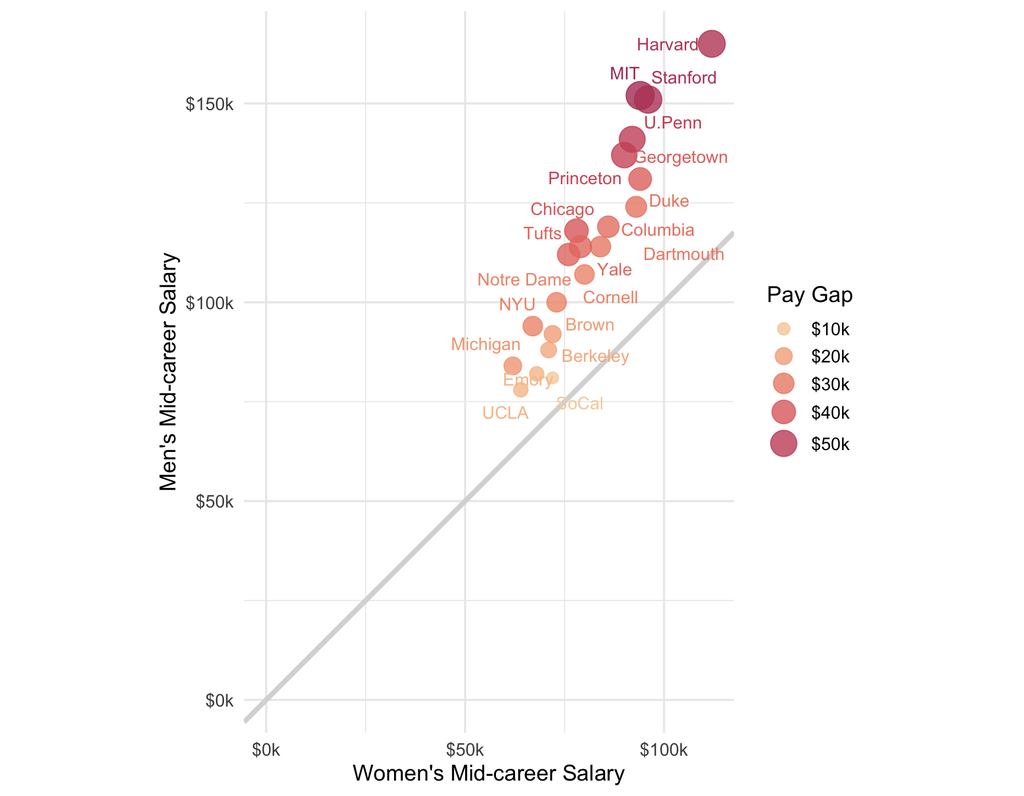